# Estado Viável mas não Cultivável: Bibliometria

Mayara Messias Oliveira

14/05/2019

## Intodução

De acordo com os fundadores Aria e Cuccurullo (2017), o pacote bibliometrix fornece um conjunto de ferramentas para pesquisa quantitativa em bibliometria e cienciometria. Essencialmente, a bibliometria é a aplicação de análises quantitativas e estatísticas a publicações como artigos de periódicos e suas respectivas contagens de citações. Estas análises são usadas para avaliar o crescimento, maturidade, autores líderes, mapas conceituais e intelectuais, tendências de uma comunidade científica. O objetivo do presente trabalho foi analisar o resultado de uma busca bibliográfica, pela base de dados SCOPUS, referente ao meu tema de trabalho de doutorado “células no estado viável mas não cultivável (VBNC)”.

## Passos utilizados para análise bibliométrica

1. Instalação do pacote Bibliometrix.

A Instalação foi feita pela ferramenta “Tools” –> “Install Packages” –> digite: “Bibliometrix” e clique em “Install”

2. Aquisição de dados bibliográficos pelo SCOPUS.

O termo utilizado para busca dos artigos foi “VBNC”.O resultado da busca foi baixado utilizando-se as ferramentamentas ‘Select All’ e ‘Export’.O arquivo foi exportado no formato “BibTeX” e foram selecionadas “todas as informações disponíveis”.

3. Carregar o pacote Bibliometrix.

```r
library(bibliometrix)
```

4. Exportar os dados adiquiridos.

O arquivo a ser exportado é lido com a função readFiles. Para dar sequencia as análises bibliométricas dos dados todas as funções devem ser guardadas dentro de um objeto do tipo vetor. Neste caso, a função readFiles foi guardada dentro do vetor D.

```r
D <- readFiles("C:/Users/Thata/Documents/Bibliometrix/scopus.bib")
```

5. Coverter os dados em um data frame.

```r
M <- convert2df(D, dbsource = "scopus", format = "bibtex")
```

```
##
## Converting your scopus collection into a bibliographic dataframe
##
## Articles extracted   100
## Articles extracted   200
## Articles extracted   300
## Articles extracted   400
## Articles extracted   500
## Articles extracted   600
## Articles extracted   700
## Articles extracted   718
## Done!
##
##
## Generating affiliation field tag AU_UN from C1:  Done!
```

6.Análise descritiva dos dados bibliográficos.

A função biblioAnalysis calcula as principais medidas bibliométricas.

```r
results <- biblioAnalysis(M, sep = ";")
```

7. Resumo dos principais resultados da análise bibliométrica.

```r
options(width=100)
S <- summary(object = results, k = 20, pause = FALSE)
```

```
##
##
## Main Information about data
##
##  Documents                             718
##  Sources (Journals, Books, etc.)       295
##  Keywords Plus (ID)                    4513
##  Author's Keywords (DE)                1542
##  Period                                1994 - 2019
##  Average citations per documents       25.97
##
##  Authors                               2118
##  Author Appearances                    3110
##  Authors of single-authored documents  41
##  Authors of multi-authored documents   2077
##  Single-authored documents             50
##
##  Documents per Author                  0.339
##  Authors per Document                  2.95
##  Co-Authors per Documents              4.33
##  Collaboration Index                   3.11
##
##  Document types
##  ARTICLE                584
##  ARTICLE IN PRESS       1
##  BOOK                   1
##  BOOK CHAPTER           28
##  CONFERENCE PAPER       18
##  CONFERENCE REVIEW      3
##  EDITORIAL              2
##  LETTER                 4
##  NOTE                   3
##  REVIEW                 66
##  SHORT SURVEY           8
##
##
## Annual Scientific Production
##
##  Year    Articles
##     1994        1
```

[output cut: 167 more lines]

```
## 6  VIABLE BUT NON CULTURABLE            25 BACTERIUM CULTURE              179
## 7  ESCHERICHIA COLI                     24 POLYMERASE CHAIN REACTION      174
## 8  VIABILITY                            24 CONTROLLED STUDY               169
## 9  VBNC STATE                           22 MICROBIOLOGY                   159
## 10 VIABLE BUT NONCULTURABLE STATE       21 BACTERIUM                      147
## 11 CULTURABILITY                        20 BACTERIA                       143
## 12 SALMONELLA                           18 PRIORITY JOURNAL               135
## 13 VIBRIO PARAHAEMOLYTICUS              18 CELL VIABILITY                 126
## 14 BIOFILM                              17 BACTERIAL                      124
## 15 DRINKING WATER                       16 FLOW CYTOMETRY                 110
## 16 LEGIONELLA                           16 GROWTH                         107
## 17 STRESS                               16 DEVELOPMENT AND AGING          103
## 18 CAMPYLOBACTER JEJUNI                 15 METABOLISM                     102
## 19 QPCR                                 15 BACTERIAL CELL                  95
## 20 STARVATION                           15 HUMANS                          95
```

8. Construção de gráficos das principais informações.

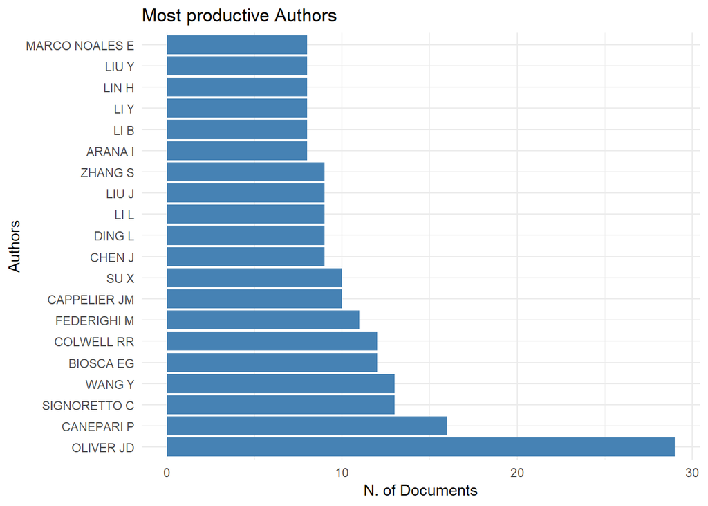

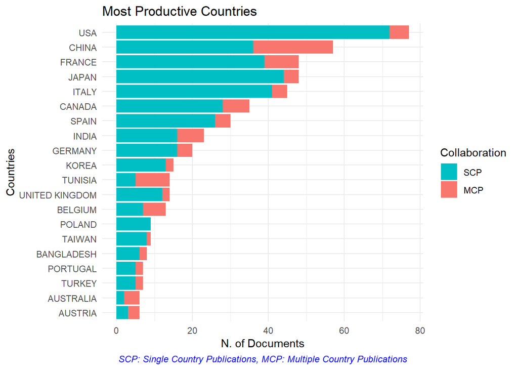

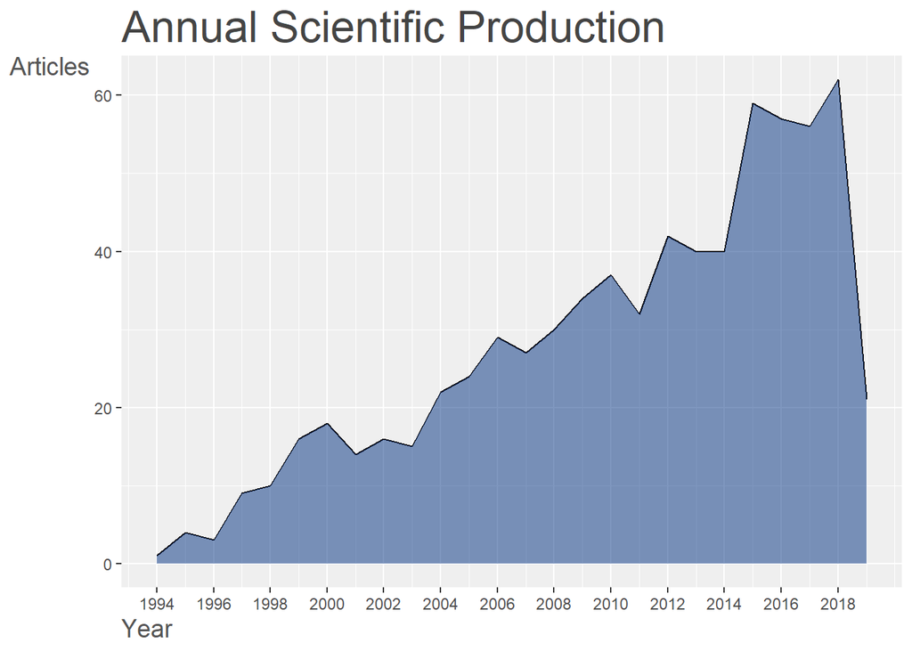

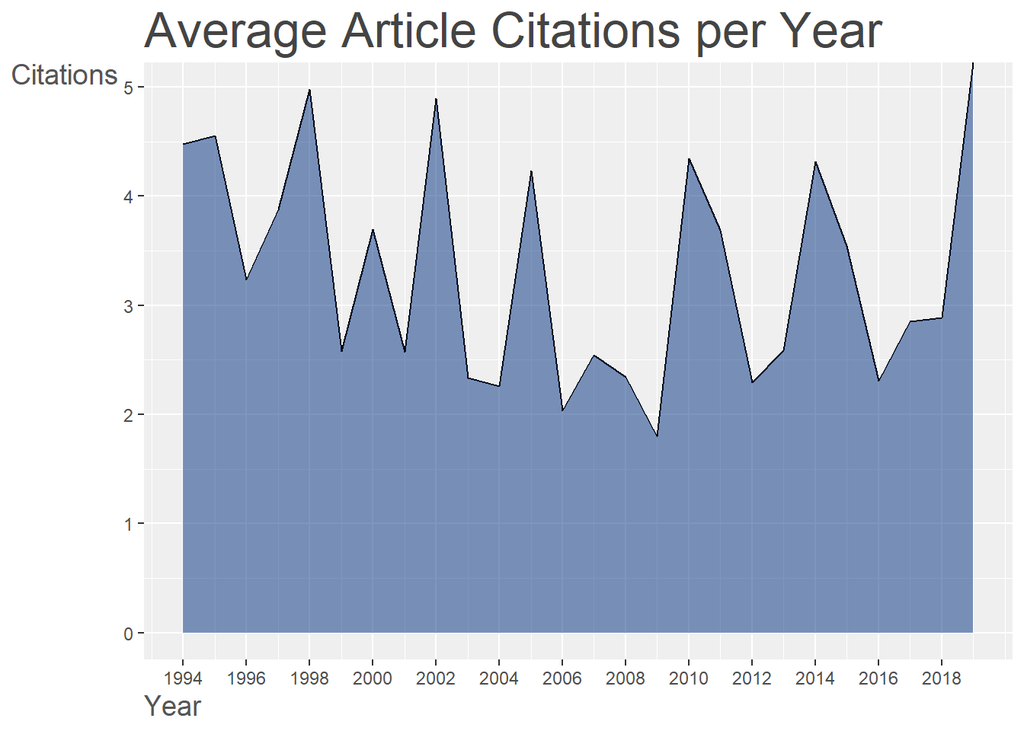

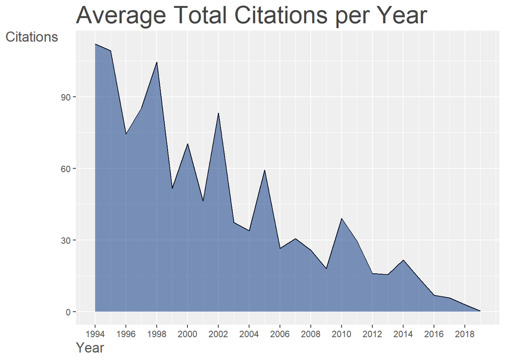

```r
plot(x = results, k = 20, pause = FALSE)
```

9. Análise das referências citadas. A função ‘citations’ gera a tabela de frequência dos artigos mais citados ou os primeiros autores mais citados.

```r
CR <- citations(M, field = "article", sep = ";")
cbind(CR$Cited[1:20])
```

```
##                                                                                                                                                                                                                                                [,1]
## OLIVER, J.D., THE VIABLE BUT NONCULTURABLE STATE IN BACTERIA (2005) J MICROBIOL, 43, PP. 93-100                                                                                                                                                  44
## OLIVER, J.D., RECENT FINDINGS ON THE VIABLE BUT NONCULTURABLE STATE IN PATHOGENIC BACTERIA (2010) FEMS MICROBIOL REV, 34, PP. 415-425                                                                                                            37
## WHITESIDES, M.D., OLIVER, J.D., RESUSCITATION OF VIBRIO VULNIFICUS FROM THE VIABLE BUT NONCULTURABLE STATE (1997) APPL. ENVIRON. MICROBIOL., 63, PP. 1002-1005                                                                                   29
## KOGURE, K., SIMIDU, U., TAGA, N., A TENTATIVE DIRECT MICROSCOPIC METHOD FOR COUNTING LIVING MARINE BACTERIA (1979) CAN. J. MICROBIOL., 25, PP. 415-420                                                                                           28
## OLIVER, J.D., RECENT FINDINGS ON THE VIABLE BUT NONCULTURABLE STATE IN PATHOGENIC BACTERIA (2010) FEMS MICROBIOL. REV., 34, PP. 415-425                                                                                                          28
## OLIVER, J.D., THE VIABLE BUT NONCULTURABLE STATE IN BACTERIA (2005) J. MICROBIOL., 43, PP. 93-100                                                                                                                                                26
## ROSZAK, D.B., COLWELL, R.R., SURVIVAL STRATEGIES OF BACTERIA IN THE NATURAL ENVIRONMENT (1987) MICROBIOL. REV., 51, PP. 365-379                                                                                                                  26
## KOGURE, K., SIMIDU, U., TAGA, N., A TENTATIVE DIRECT MICROSCOPIC METHOD FOR COUNTING LIVING MARINE BACTERIA (1979) CAN J MICROBIOL, 25, PP. 415-420                                                                                              21
## OLIVER, J.D., BOCKIAN, R., IN VIVO RESUSCITATION, AND VIRULENCE TOWARDS MICE, OF VIABLE BUT NONCULTURABLE CELLS OF VIBRIO VULNIFICUS (1995) APPL. ENVIRON. MICROBIOL., 61, PP. 2620-2623                                                         21
## WHITESIDES, M.D., OLIVER, J.D., RESUSCITATION OF VIBRIO VULNIFICUS FROM THE VIABLE BUT NONCULTURABLE STATE (1997) APPL ENVIRON MICROBIOL, 63, PP. 1002-1005                                                                                      21
## KELL, D.B., KAPRELYANTS, A.S., WEICHART, D.H., HARWOOD, C.R., BARER, M.R., VIABILITY AND ACTIVITY IN READILY CULTURABLE BACTERIA: A REVIEW AND DISCUSSION OF THE PRACTICAL ISSUES (1998) ANTONIE VAN LEEUWENHOEK, 73, PP. 169-187                19
## NILSSON, L., OLIVER, J.D., KJELLEBERG, S., RESUSCITATION OF VIBRIO VULNIFICUS FROM THE VIABLE BUT NONCULTURABLE STATE (1991) J. BACTERIOL., 173, PP. 5054-5059                                                                                   19
## OLIVER, J.D., BOCKIAN, R., IN VIVO RESUSCITATION, AND VIRULENCE TOWARDS MICE, OF VIABLE BUT NONCULTURABLE CELLS OF VIBRIO VULNIFICUS (1995) APPL ENVIRON MICROBIOL, 61, PP. 2620-2623                                                            19
## ROSZAK, D.B., COLWELL, R.R., SURVIVAL STRATEGIES OF BACTERIA IN THE NATURAL ENVIRONMENT (1987) MICROBIOL REV, 51, PP. 365-379                                                                                                                    19
## OLIVER, J.D., HITE, F., MCDOUGALD, D., ANDON, N.L., SIMPSON, L.M., ENTRY INTO, AND RESUSCITATION FROM, THE VIABLE BUT NONCULTURABLE STATE BY VIBRIO VULNIFICUS IN AN ESTUARINE ENVIRONMENT (1995) APPL. ENVIRON. MICROBIOL., 61, PP. 2624-2630   18
## NILSSON, L., OLIVER, J.D., KJELLEBERG, S., RESUSCITATION OF VIBRIO VULNIFICUS FROM THE VIABLE BUT NONCULTURABLE STATE (1991) J BACTERIOL, 173, PP. 5054-5059                                                                                     17
## OLIVER, J.D., NILSSON, L., KJELLEBERG, S., FORMATION OF NONCULTURABLE VIBRIO VULNIFICUS CELLS AND ITS RELATIONSHIP TO THE STARVATION STATE (1991) APPL. ENVIRON. MICROBIOL., 57, PP. 2640-2644                                                   16
## ROLLINS, D.M., COLWELL, R.R., VIABLE BUT NONCULTURABLE STAGE OF CAMPYLOBACTER JEJUNI AND ITS ROLE IN SURVIVAL IN THE NATURAL AQUATIC ENVIRONMENT (1986) APPL. ENVIRON. MICROBIOL., 52, PP. 531-538                                               16
## WEICHART, D., KJELLEBERG, S., STRESS RESISTANCE AND RECOVERY POTENTIAL OF CULTURABLE AND VIABLE BUT NONCULTURABLE CELLS OF VIBRIO VULNIFICUS (1996) MICROBIOLOGY, 142, PP. 845-853                                                               16
## OLIVER, J.D., RECENT FINDINGS ON THE VIABLE BUT NONCULTURABLE STATE IN PATHOGENIC BACTERIA (2010) FEMS MICROBIOL. REV, 34, PP. 415-425                                                                                                           15
```

Para verificar como os arquivos estão separados, pode-se utilizar:

```r
M$CR[1]
```

```
## [1] "ABD EL-AZIZ, N.K., TARTOR, Y.H., GHARIB, A.A.E., AMMAR, A.M., PROPIDIUM MONOAZIDE QUANTITATIVE REAL-TIME POLYMERASE CHAIN REACTION FOR ENUMERATION OF SOME VIABLE BUT NONCULTURABLE FOODBORNE BACTERIA IN MEAT AND MEAT PRODUCTS (2018) FOODBORNE PATHOGENS AND DISEASE, 15 (4), PP. 226-234; AYRAPE…
```

Para obter os primeiros autores citados mais frequentes:

```r
CR <- citations(M, field = "author", sep = ";")
cbind(CR$Cited[1:20])
```

```
##                 [,1]
## OLIVER J D      1618
## COLWELL R R     1309
## CANEPARI P       387
## KJELLEBERG S     345
## GRIMES D J       329
## KAPRELYANTS A S  297
## KELL D B         291
## SIGNORETTO C     286
## FEDERIGHI M      261
## CAPPELIER J M    248
## HUQ A            244
## ROSZAK D B       229
## TAFI M C         227
## LI L             193
## LLE M M          184
## BARCINA I        177
## BARER M R        177
## XU H S           176
## ASAKURA H        162
## MCDOUGALD D      162
```

10. Ranking de dominância dos autores.

O fator de dominância é uma razão que indica a fração de artigos com vários autores em que um pesquisador aparece como primeiro autor.

```r
DF <- dominance(results, k = 20)
DF
```

```
##          Author Dominance Factor Tot Articles Single-Authored Multi-Authored First-Authored Rank by Articles Rank by DF
## 1  SANTANDER RD        0.8571429            7               0              7              6                1          1
## 2          SU X        0.7777778           10               1              9              7               15          2
## 3         LIU J        0.6666667            9               0              9              6               11          3
## 4         LIU Y        0.6250000            8               0              8              5                5          4
## 5  CAPPELIER JM        0.5000000           10               0             10              5               15          5
## 6       ARANA I        0.5000000            8               0              8              4                5          5
## 7          LI Y        0.5000000            8               0              8              4                5          5
## 8       ZHANG S        0.3333333            9               0              9              3               11          8
## 9  SIGNORETTO C        0.3076923           13               0             13              4               18          9
## 10       WANG C        0.2857143            7               0              7              2                1         10
## 11         XU Z        0.2500000            8               0              8              2                5         11
## 12       DING L        0.2222222            9               0              9              2               11         12
## 13    BIOSCA EG        0.1666667           12               0             12              2               17         13
## 14    OLIVER JD        0.1538462           29               3             26              4               20         14
## 15       WANG Y        0.1538462           13               0             13              2               18         14
## 16    BARCINA I        0.1428571            7               0              7              1                1         16
## 17   CITTERIO B        0.1428571            7               0              7              1                1         16
## 18        LIN H        0.1250000            8               0              8              1                5         18
## 19         YU X        0.1250000            8               0              8              1                5         18
## 20         LI L        0.1111111            9               0              9              1               11         20
```

11.H-Index dos autores

O índice h é uma métrica no nível do autor que tenta medir o impacto da produtividade e da citação das publicações de um pesquisador.

O índice baseia-se no conjunto de artigos mais citados pelos cientistas e no número de citações que receberam em outras publicações.

A função Hindex calcula o índice H dos autores ou o índice H das fontes e suas variantes (índice-g e índice-m) em uma coleção bibliográfica.

Os argumentos da função são: M um quadro de dados bibliográficos; field é o elemento de caractere que define a unidade de análise em termos de autores (campo = “auhtor”) ou fontes (campo = “fonte”); elementos um vetor de caractere contendo os nomes dos autores (ou os nomes das fontes) para os quais você deseja calcular o índice-H. O argumento tem a forma c (“SURNAME1 N”, “SURNAME2 N”,…).

```r
indices <- Hindex(M, field = "author", elements="OLIVER JD", sep = ";", years = 10)
indices$H
```

```
##      Author h_index g_index   m_index   TC NP PY_start
## 1 OLIVER JD       9      13 0.8181818 1046 13     2009
```

Lista de citações

```r
indices$CitationList
```

```
## [[1]]
##                           Authors                        Journal Year TotalCitation
## 2  AYRAPETYAN M;WILLIAMS TC;OLIVE STRESS AND ENVIRONMENTAL REGUL 2016             0
## 10 SANTANDER RD;OLIVER JD;BIOSCA  MICROBES IN APPLIED RESEARCH:  2012             0
## 1  AYRAPETYAN M;WILLIAMS T;OLIVER        JOURNAL OF BACTERIOLOGY 2018             2
## 4                       OLIVER JD                        MICROBE 2016             5
## 3          AYRAPETYAN M;OLIVER JD CURRENT OPINION IN FOOD SCIENC 2016            20
## 5  AYRAPETYAN M;WILLIAMS TC;BAXTE         INFECTION AND IMMUNITY 2015            26
## 11               BUCK A;OLIVER JD                   FOOD CONTROL 2010            26
## 8  AYRAPETYAN M;WILLIAMS TC;OLIVE APPLIED AND ENVIRONMENTAL MICR 2014            30
## 13 CUNNINGHAM E;O BYRNE C;OLIVER                    FOOD CONTROL 2009            33
## 9          NOWAKOWSKA J;OLIVER JD      FEMS MICROBIOLOGY ECOLOGY 2013            57
## 6  AYRAPETYAN M;WILLIAMS TC;OLIVE         TRENDS IN MICROBIOLOGY 2015            78
## 7  LI L;MENDIS N;TRIGUI H;OLIVER       FRONTIERS IN MICROBIOLOGY 2014           223
## 12                      OLIVER JD      FEMS MICROBIOLOGY REVIEWS 2010           546
```

H-Index dos 20 autores mais produtivos

```r
authors=gsub(","," ",names(results$Authors)[1:20])

indices <- Hindex(M, field = "author", elements=authors, sep = ";", years = 50)

indices$H
```

```
##            Author h_index g_index   m_index   TC NP PY_start
## 1       OLIVER JD      22      29 0.8800000 2963 29     1995
## 2      CANEPARI P      13      16 0.6500000  893 16     2000
## 3    SIGNORETTO C      10      13 0.5000000  669 13     2000
## 4          WANG Y       6      13 0.4615385  176 13     2007
## 5       BIOSCA EG       6      12 0.4285714  165 12     2006
## 6      COLWELL RR      12      12 0.4615385  685 12     1994
## 7     FEDERIGHI M      10      11 0.4761905  580 11     1999
## 8    CAPPELIER JM      10      10 0.4545455  547 10     1998
## 9            SU X       6       9 0.6666667   87 11     2011
## 10         CHEN J       6       9 0.4615385  156  9     2007
## 11         DING L       6       9 0.6666667   96 11     2011
## 12           LI L       5      10 0.8333333  325 10     2014
## 13          LIU J       4      10 0.6666667  104 10     2014
## 14        ZHANG S       4       9 0.8000000  103  9     2015
## 15        ARANA I       7       8 0.4117647  171  8     2003
## 16           LI B       4       8 1.0000000  101  8     2016
## 17           LI Y       4       8 0.3076923  107  8     2007
## 18          LIN H       4       9 0.5000000  108  9     2012
## 19          LIU Y       4      10 0.3333333  170 10     2008
## 20 MARCO NOALES E       6       8 0.4285714  148  8     2006
```

12.Produtividade dos principais autores ao longo do tempo

A função AuthorProdOverTime calcula e plota a produção dos autores (em termos de número de publicações e total de citações por ano) ao longo do tempo.

Os argumentos da função são: M um quadro de dados bibliográficos; k é o número de k Top Autores; gráfico é uma lógica. Se graph = TRUE, a função plota o gráfico de produção do autor ao longo do tempo.

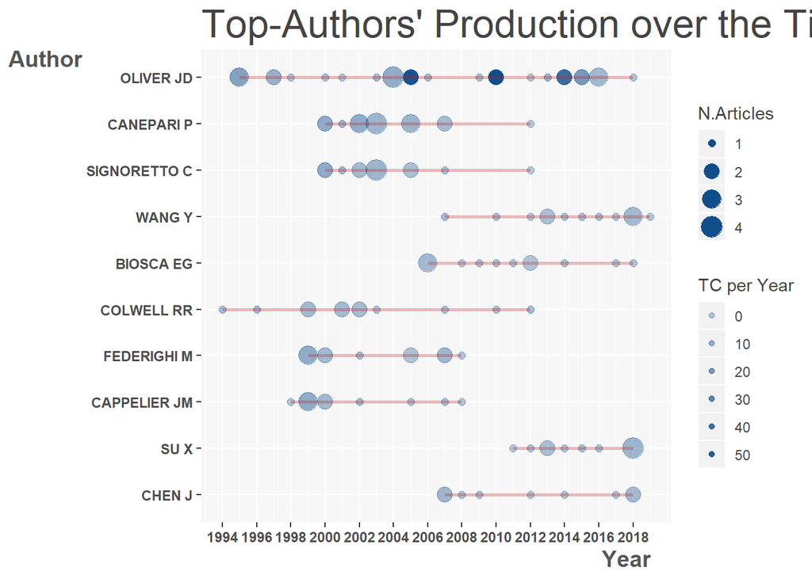

```r
topAU <- authorProdOverTime(M, k = 10, graph = TRUE)
```

Tabela: Produtividade do autor por ano

```r
head(topAU$dfAU)
```

```
##      Author year freq TC     TCpY
## 1 BIOSCA EG 2006    3 82 5.857143
## 2 BIOSCA EG 2008    1  6 0.500000
## 3 BIOSCA EG 2009    1 29 2.636364
## 4 BIOSCA EG 2010    1 23 2.300000
## 5 BIOSCA EG 2011    1  0 0.000000
## 6 BIOSCA EG 2012    2  8 1.000000
```

Tabela: Lista de documento dos autores

```r
head(topAU$dfPapersAU)
```

```
##      Author year
## 2 OLIVER JD 2018
## 3 OLIVER JD 2016
## 4 OLIVER JD 2016
## 5 OLIVER JD 2016
## 6 OLIVER JD 2015
## 7 OLIVER JD 2015
##                                                                                                                                                                                                                             TI
## 2                                                                                                                                       RELATIONSHIP BETWEEN THE VIABLE BUT NONCULTURABLE STATE AND ANTIBIOTIC PERSISTER CELLS
## 3                                                                                                                      RESUSCITATION OF VIBRIOS FROM THE VIABLE BUT NONCULTURABLE STATE IS INDUCED BY QUORUM-SENSING MOLECULES
## 4                                                                                                                                                         THE VIABLE BUT NON-CULTURABLE STATE AND ITS RELEVANCE IN FOOD SAFETY
## 5 THE VIABLE BUT NONCULTURABLE STATE FOR BACTERIA: STATUS UPDATE: THIS DORMANT FORM OF BACTERIA WAS FIRST APPRECIATED IN 1982, NOW SKEPTICS RECOGNIZE THIS STATE AS A BACTERIAL RESPONSE TO STRESS AND A STRATEGY FOR SURVIVAL
## 6                                                                                                                           VIABLE BUT NONCULTURABLE AND PERSISTER CELLS COEXIST STOCHASTICALLY AND ARE INDUCED BY HUMAN SERUM
## 7                                                                                                                                        BRIDGING THE GAP BETWEEN VIABLE BUT NON-CULTURABLE AND ANTIBIOTIC PERSISTENT BACTERIA
##                                                                                  SO                         DOI TC
## 2                                                           JOURNAL OF BACTERIOLOGY         10.1128/JB.00249-18  2
## 3 STRESS AND ENVIRONMENTAL REGULATION OF GENE EXPRESSION AND ADAPTATION IN BACTERIA 10.1002/9781119004813.CH130  0
## 4                                                   CURRENT OPINION IN FOOD SCIENCE  10.1016/J.COFS.2016.04.010 20
## 5                                                                           MICROBE    10.1128/MICROBE.11.159.1  5
## 6                                                            INFECTION AND IMMUNITY        10.1128/IAI.00404-15 26
## 7                                                            TRENDS IN MICROBIOLOGY   10.1016/J.TIM.2014.09.004 78
##    TCpY
## 2  1.00
## 3  0.00
## 4  5.00
## 5  1.25
## 6  5.20
## 7 15.60
```

13. Matrizes de rede bibliográfica

Redes Bipartidas

cocMatrix é uma função geral para calcular uma rede bipartida selecionando um dos atributos de metadados.

Por exemplo, para criar uma rede de Manuscrito x Fonte de publicação, é preciso usar a tag de campo “SO”.

```r
A <- cocMatrix(M, Field = "SO", sep = ";")
```

Classificando, em ordem decrescente, as somas da coluna de A, é possível ver as fontes de publicação mais relevantes.

```r
sort(Matrix::colSums(A), decreasing = TRUE)[1:10]
```

```
##     APPLIED AND ENVIRONMENTAL MICROBIOLOGY            JOURNAL OF APPLIED MICROBIOLOGY
##                                         49                                         26
##                  FRONTIERS IN MICROBIOLOGY INTERNATIONAL JOURNAL OF FOOD MICROBIOLOGY
##                                         22                                         18
##         JOURNAL OF MICROBIOLOGICAL METHODS                  FEMS MICROBIOLOGY ECOLOGY
##                                         16                                         15
##                               FOOD CONTROL                             WATER RESEARCH
##                                         14                                         13
##            LETTERS IN APPLIED MICROBIOLOGY                          FOOD MICROBIOLOGY
##                                         13                                         12
```

O mesmo pode ser usado para calcular várias redes bipartidas:

Rede de Citação

```r
A <- cocMatrix(M, Field = "CR", sep = ".")
```

Rede de autores

```r
A <- cocMatrix(M, Field = "AU", sep = ";")
```

Rede de países

```r
M <- metaTagExtraction(M, Field = "AU_CO", sep = ";")
A <- cocMatrix(M, Field = "AU_CO", sep = ";")
```

```r
NetMatrix <- biblioNetwork(M, analysis = "coupling", network = "references", sep = ".  ")
```

Rede de palavra-chave

```r
A <- cocMatrix(M, Field = "ID", sep = ";")
```

Acoplamento bibliográfico

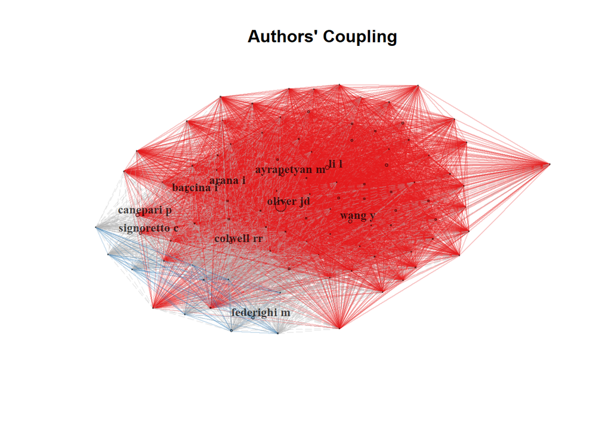

```r
NetMatrix <- biblioNetwork(M, analysis = "coupling", network = "authors", sep = ";")

net=networkPlot(NetMatrix,  normalize = "salton", weighted=NULL, n = 100, Title = "Authors' Coupling", type = "fruchterman", size=5,size.cex=T,remove.multiple=TRUE,labelsize=0.8,label.n=10,label.cex=F)
```

Co-citação bibliográfica

A função biblioNetwork também pode ser usada para calcular a rede de colaboração de um autor ou uma rede de colaboração do país, como é mostrado abaixo:

```r
NetMatrix <- biblioNetwork(M, analysis = "co-citation", network = "references", sep = ".  ")
```

```r
NetMatrix <- biblioNetwork(M, analysis = "collaboration", network = "countries", sep = ";")
```

14. Análise descritiva das características do gráfico de rede

A função networkStat calcula várias estatísticas de resumo.

Partindo de uma matriz bibliográfica (ou um objeto igraph), são computados grupos de medidas descritivas.

Rede clássica de co-ocorrências de palavras-chave:

```r
NetMatrix <- biblioNetwork(M, analysis = "co-occurrences", network = "keywords", sep = ";")
netstat <- networkStat(NetMatrix)
```

```r
names(netstat$network)
```

```
##  [1] "networkSize"             "networkDensity"          "networkTransitivity"     "networkDiameter"
##  [5] "networkDegreeDist"       "networkCentrDegree"      "networkCentrCloseness"   "networkCentrEigen"
##  [9] "networkCentrbetweenness" "NetworkAverPathLeng"
```

Principais índices de centralidade e prestígio dos vértices

Essas medidas ajudam a identificar os vértices mais importantes em uma rede e a propensão de dois vértices que estão conectados para estar ambos conectados a um terceiro vértice.

```r
names(netstat$vertex)
```

Para resumir os principais resultados da função networkStat, use o resumo da função genérica. Ele exibe as principais informações sobre a rede e a descrição do vértice através de várias tabelas.

k é um valor de formatação que indica o número de linhas de cada tabela.

```r
summary(netstat, k=10)
```

```
##
##
## Main statistics about the network
##
##  Size                                  4542
##  Density                               0.02
##  Transitivity                          0.18
##  Diameter                              4
##  Degree Centralization                 0.75
##  Average path length                   2.082
##
```

15. Visualizando redes bibliográficas

Com a função networkPlot é possível plotar uma rede criada pela biblioNetwork usando rotinas R ou usando o VOSviewer.

O argumento principal do networkPlot é type. Indica o layout do mapa de rede: circle, kamada-kawai, mds, etc.

Colaboração Científica no País

Crie uma rede de colaboração no país:

```r
M <- metaTagExtraction(M, Field = "AU_CO", sep = ";")
NetMatrix <- biblioNetwork(M, analysis = "collaboration", network = "countries", sep = ";")
```

Gráfico da rede de colaboração:

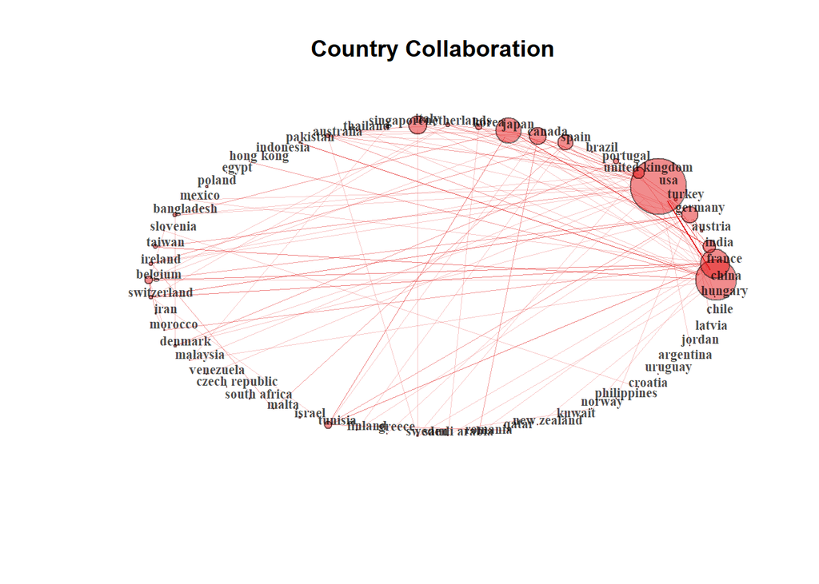

```r
net=networkPlot(NetMatrix, n = dim(NetMatrix)[1], Title = "Country Collaboration", type = "circle", size=TRUE, remove.multiple=FALSE,labelsize=0.7,cluster="none")
```

Rede de co-citação

Crie uma rede de co-citação:

```r
NetMatrix <- biblioNetwork(M, analysis = "co-citation", network = "references", sep = ";")
```

Gráfico da rede de co-citação:

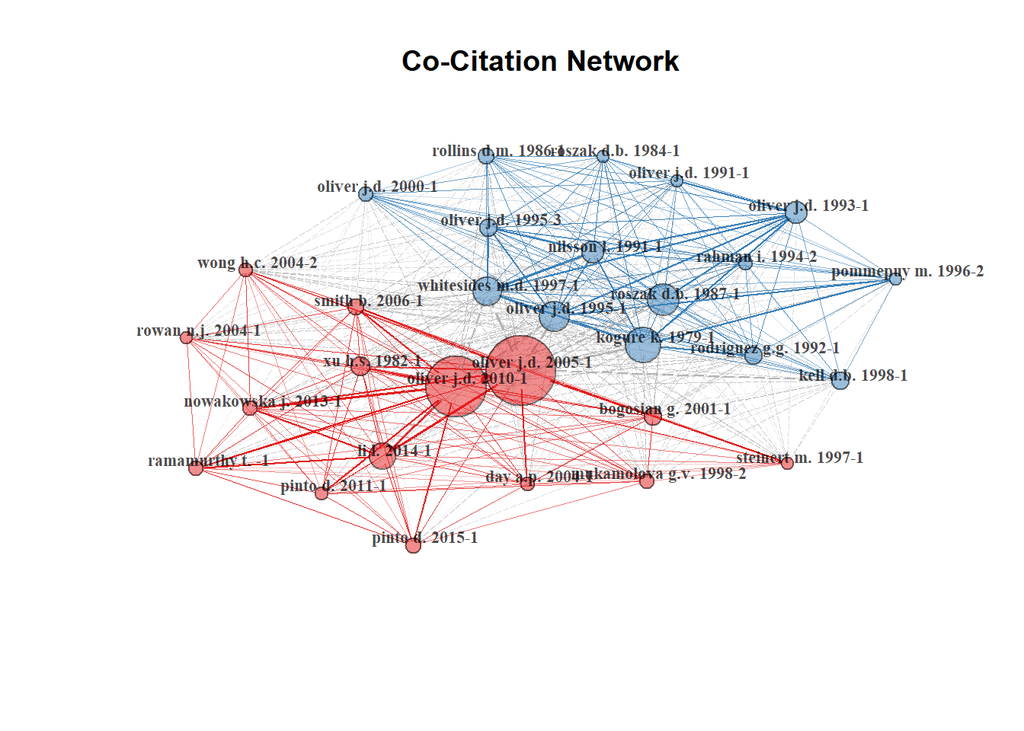

```r
net=networkPlot(NetMatrix, n = 30, Title = "Co-Citation Network", type = "fruchterman", size=T, remove.multiple=FALSE, labelsize=0.7,edgesize = 5)
```

Co-ocorrências de palavras-chave

Rede de co-ocorrências de palavras-chave:

```r
NetMatrix <- biblioNetwork(M, analysis = "co-occurrences", network = "keywords", sep = ";")
```

Gráfico da rede de co-ocorrências de palavras-chave:

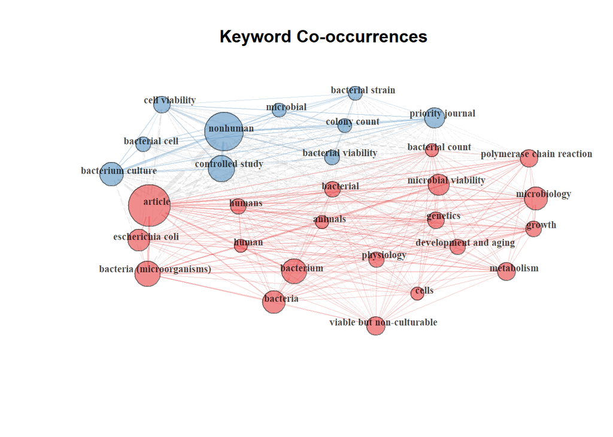

```r
net=networkPlot(NetMatrix, normalize="association", weighted=T, n = 30, Title = "Keyword Co-occurrences", type = "fruchterman", size=T,edgesize = 5,labelsize=0.7)
```

16. Análise Co-Word

O objetivo da análise conjunta é mapear a estrutura conceitual de um framework usando a palavra co-ocorrências em uma coleção bibliográfica.

A análise pode ser realizada por meio de técnicas de redução de dimensionalidade, como Escala Multidimensional (MDS), Análise de Correspondência (AC) ou Análise de Correspondência Múltipla (ACM).

A função conceptualStructure executa uma CA ou MCA para desenhar uma estrutura conceitual do campo e o K-means agrupa para identificar clusters de documentos que expressam conceitos comuns. Os resultados são plotados em um mapa bidimensional.